# R语言与机器学习（上）

## 6.5 软间隔与C参数

### 软间隔SVM

当数据存在噪声或异常值时，允许部分样本误分类：

$$\min_{w,b,\xi} \frac{1}{2}\|w\|^2 + C
\sum_{i=1}^{n} \xi_i$$

**C参数**：控制误分类惩罚程度。

- **C大**：严格惩罚误分类，可能过拟合
- **C小**：容忍误分类，可能欠拟合

```r
# C参数影响示例
set.seed(42)

# 创建有噪声的数据
n <- 100
x1 <- c(rnorm(n/2, 2, 1), rnorm(n/2, 4, 1))
x2 <- c(rnorm(n/2, 2, 1), rnorm(n/2, 4, 1))
y <- factor(c(rep(-1, n/2), rep(1, n/2)))

noisy_data <- data.frame(x1 = x1, x2 = x2, y = y)

# 不同C值
svm_c01 <- e1071::svm(y ~ x1 + x2, data = noisy_data,
                       kernel = "radial", cost = 0.1)
svm_c1 <- e1071::svm(y ~ x1 + x2, data = noisy_data,
                      kernel = "radial", cost = 1)
svm_c100 <- e1071::svm(y ~ x1 + x2, data = noisy_data,
                        kernel = "radial", cost = 100)

# 比较支持向量数量
c_compare <- data.frame(
  C值 = c("0.1", "1", "100"),
  支持向量数 = c(length(svm_c01$index), length(svm_c1$index), length(svm_c100$index))
)

print(c_compare)
```

```
##   C值 支持向量数
## 1 0.1         63
## 2   1         29
## 3 100         17
```

## 6.6 核主成分分析（KPCA）

### KPCA原理

**核主成分分析**将PCA扩展到非线性情况，通过核函数在高维空间进行主成分分析。

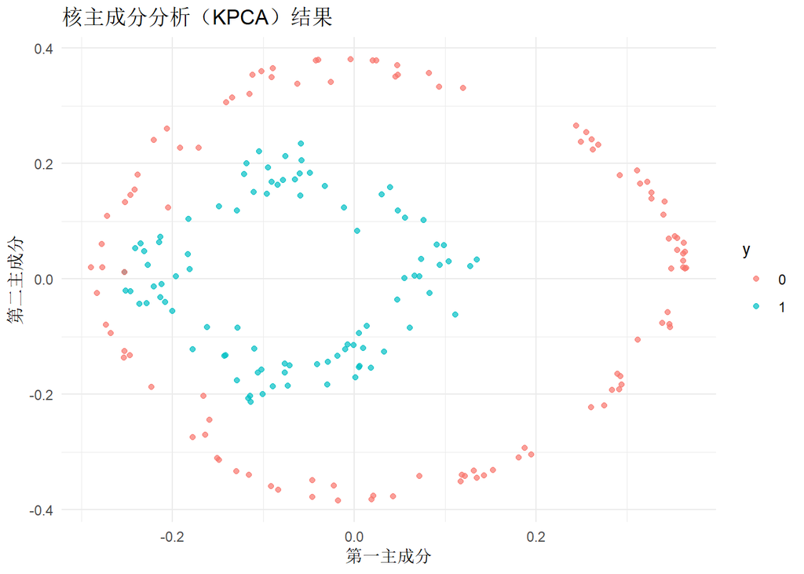

```r
# KPCA示例
set.seed(42)

# 创建同心圆数据
n <- 200
theta <- runif(n, 0, 2 * pi)
r <- ifelse(sample(c(0, 1), n, replace = TRUE) == 0,
            runif(n, 0.3, 0.5), runif(n, 0.8, 1))
x1 <- r * cos(theta)
x2 <- r * sin(theta)
y <- factor(ifelse(r < 0.6, 0, 1))

kpca_data <- data.frame(x1 = x1, x2 = x2, y = y)

# 使用kernlab包进行KPCA
if (requireNamespace("kernlab", quietly = TRUE)) {
  kpca_result <- kernlab::kpca(~ x1 + x2,
                                data = kpca_data,
                                kernel = "rbfdot",
                                kpar = list(sigma = 5))

  # 提取主成分
  pc_scores <- kernlab::pcv(kpca_result)
  kpca_data$PC1 <- pc_scores[, 1]
  kpca_data$PC2 <- pc_scores[, 2]

  # 可视化KPCA结果
  ggplot2::ggplot(kpca_data, ggplot2::aes(x = PC1, y = PC2, color = y)) +
    ggplot2::geom_point(alpha = 0.7) +
    ggplot2::labs(
      title = "核主成分分析（KPCA）结果",
      x = "第一主成分", y = "第二主成分"
    ) +
    ggplot2::theme_minimal()
}
```

## 6.7 模型调优

### 核参数选择

**RBF核的两个关键参数**：

- **C**：正则化参数
- **gamma**：核宽度参数

```r
# 使用caret进行SVM调参
set.seed(42)

# 定义参数网格
tune_grid <- expand.grid(
  sigma = c(0.01, 0.1, 1, 10),
  C = c(0.1, 1, 10, 100)
)

# 使用caret调参
svm_tune <- caret::train(
  y ~ x1 + x2,
  data = nonlinear_data,
  method = "svmRadial",
  trControl = caret::trainControl(method = "cv", number = 5),
  tuneGrid = tune_grid
)

# 查看调参结果
print(svm_tune)
```

```
## Support Vector Machines with Radial Basis Function Kernel
##
## 200 samples
##   2 predictor
##   2 classes: '0', '1'
##
## No pre-processing
## Resampling: Cross-Validated (5 fold)
## Summary of sample sizes: 161, 160, 159, 160, 160
## Resampling results across tuning parameters:
##
##   sigma  C      Accuracy   Kappa
##    0.01    0.1  0.5350094  0.0000000
##    0.01    1.0  0.5350094  0.0000000
##    0.01   10.0  0.9900000  0.9795918
##    0.01  100.0  1.0000000  1.0000000
##    0.10    0.1  0.9008474  0.7952015
##    0.10    1.0  1.0000000  1.0000000
##    0.10   10.0  1.0000000  1.0000000
##    0.10  100.0  1.0000000  1.0000000
##    1.00    0.1  1.0000000  1.0000000
##    1.00    1.0  1.0000000  1.0000000
##    1.00   10.0  1.0000000  1.0000000
##    1.00  100.0  1.0000000  1.0000000
##   10.00    0.1  0.8900969  0.7823357
##   10.00    1.0  1.0000000  1.0000000
##   10.00   10.0  1.0000000  1.0000000
##   10.00  100.0  1.0000000  1.0000000
##
## Accuracy was used to select the optimal model using the largest value.
## The final values used for the model were sigma = 1 and C = 0.1.
```

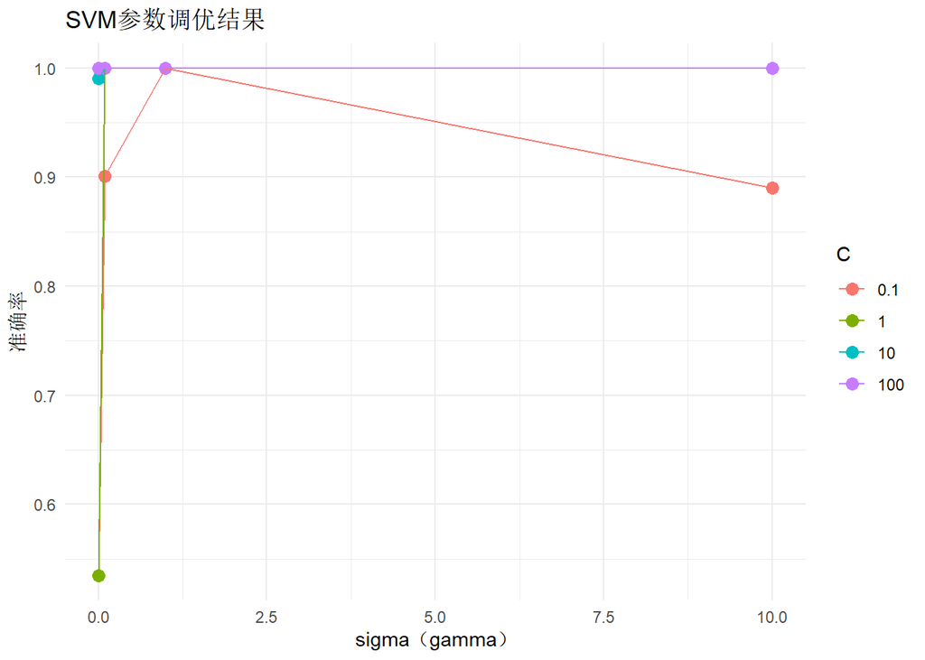

```r
# 可视化调参结果
ggplot2::ggplot(svm_tune$results, ggplot2::aes(x = sigma, y = Accuracy, color = factor(C))) +
  ggplot2::geom_point(size = 3) +
  ggplot2::geom_line() +
  ggplot2::labs(
    title = "SVM参数调优结果",
    x = "sigma（gamma）", y = "准确率", color = "C"
  ) +
  ggplot2::theme_minimal()
```

### C与gamma的影响

| 参数 | 小值 | 大值 |
| --- | --- | --- |
| C | 宽松边界，可能欠拟合 | 严格边界，可能过拟合 |
| gamma | 决策边界平滑 | 决策边界复杂 |

### 意义与使用场景

**核心意义**：SVM通过核技巧处理非线性问题，在中小规模数据上表现优异。

**举例**：医学图像分类

**场景**：区分良性和恶性肿瘤的医学图像。

**为什么用SVM？**

医学图像数据通常特征维度高、样本量中等。SVM的核方法能有效处理高维数据，且具有良好的泛化能力。RBF核能自动适应复杂的决策边界。

# 第七章 最近邻与基于实例的方法

## 7.1 K近邻（KNN）基础

### 基本原理

**K近邻（K-Nearest Neighbors, KNN）**是一种基于实例的学习方法：

1. 计算待预测样本与所有训练样本的距离
2. 选择距离最近的K个邻居
3. **分类**：K个邻居中多数类作为预测结果
4. **回归**：K个邻居的平均值作为预测结果

```r
# KNN分类示例
set.seed(42)

# 创建模拟数据
n <- 200
knn_data <- data.frame(
  feature1 = c(rnorm(n/2, mean = 2, sd = 1), rnorm(n/2, mean = 5, sd = 1)),
  feature2 = c(rnorm(n/2, mean = 2, sd = 1), rnorm(n/2, mean = 5, sd = 1)),
  class = factor(c(rep("A", n/2), rep("B", n/2)))
)

# 划分训练集和测试集
train_idx <- sample(1:n, 0.7 * n)
train_data <- knn_data[train_idx, ]
test_data <- knn_data[-train_idx, ]

# 使用class包进行KNN分类
knn_pred <- class::knn(
  train = train_data[, c("feature1", "feature2")],
  test = test_data[, c("feature1", "feature2")],
  cl = train_data$class,
  k = 5
)

# 计算准确率
accuracy <- mean(knn_pred == test_data$class)
print(paste("KNN准确率:", round(accuracy, 3)))
```

```
## [1] "KNN准确率: 0.983"
```

```r
# 混淆矩阵
table(实际 = test_data$class, 预测 = knn_pred)
```

```
##     预测
## 实际  A  B
##    A 30  1
##    B  0 29
```

### 可视化KNN决策边界

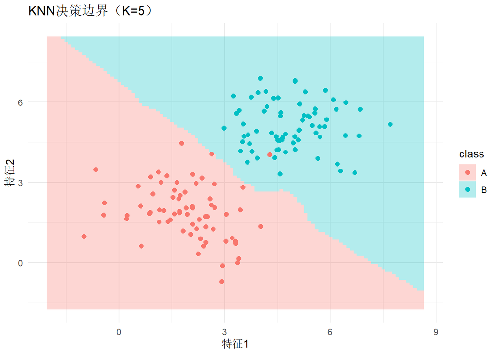

```r
# 创建网格用于可视化决策边界
grid_x1 <- seq(min(knn_data$feature1) - 1, max(knn_data$feature1) + 1, by = 0.1)
grid_x2 <- seq(min(knn_data$feature2) - 1, max(knn_data$feature2) + 1, by = 0.1)
grid <- expand.grid(feature1 = grid_x1, feature2 = grid_x2)

# 预测网格点的类别
grid_pred <- class::knn(
  train = train_data[, c("feature1", "feature2")],
  test = grid,
  cl = train_data$class,
  k = 5
)

grid$class <- grid_pred

# 可视化
ggplot2::ggplot() +
  ggplot2::geom_tile(data = grid, ggplot2::aes(x = feature1, y = feature2, fill = class), alpha = 0.3) +
  ggplot2::geom_point(data = train_data, ggplot2::aes(x = feature1, y = feature2, color = class), size = 2) +
  ggplot2::labs(
    title = "KNN决策边界（K=5）",
    x = "特征1", y = "特征2"
  ) +
  ggplot2::theme_minimal()
```

## 7.2 距离度量

### 常用距离公式

**欧氏距离（Euclidean Distance）**：

$$d(x, y) = \sqrt{\sum_{i=1}^{p}(x_i -
y_i)^2}$$

**曼哈顿距离（Manhattan Distance）**：

$$d(x, y) = \sum_{i=1}^{p}|x_i -
y_i|$$

**闵可夫斯基距离（Minkowski Distance）**：

$$d(x, y) = \left(\sum_{i=1}^{p}|x_i -
y_i|^q\right)^{1/q}$$

当$q=2$时为欧氏距离，$q=1$时为曼哈顿距离。

```r
# 比较不同距离度量
# 欧氏距离（默认）
knn_euclidean <- class::knn(
  train = train_data[, c("feature1", "feature2")],
  test = test_data[, c("feature1", "feature2")],
  cl = train_data$class,
  k = 5
)

# 使用caret比较不同距离度量
knn_manhattan <- caret::knn3(
  class ~ feature1 + feature2,
  data = train_data,
  k = 5
)

# 预测
pred_manhattan <- predict(knn_manhattan, test_data[, c("feature1", "feature2")], type = "class")

# 比较
distance_compare <- data.frame(
  距离度量 = c("欧氏距离", "曼哈顿距离"),
  准确率 = c(
    mean(knn_euclidean == test_data$class),
    mean(pred_manhattan == test_data$class)
  )
)

print(distance_compare)
```

[output not shown]

## 7.3 加权KNN

### 加权原理

**加权KNN**：距离越近的邻居权重越大，减少K值选择的影响。

常用权重函数：

$$w_i = \frac{1}{d(x, x_i)^2}$$

```r
# 加权KNN示例
# 使用kknn包
if (requireNamespace("kknn", quietly = TRUE)) {
  library(kknn)

  # 训练加权KNN
  weighted_knn <- kknn::kknn(
    class ~ feature1 + feature2,
    train = train_data,
    test = test_data,
    k = 5,
    distance = 2,  # 欧氏距离
    kernel = "gaussian"  # 高斯核权重
  )

  # 预测
  weighted_pred <- fitted(weighted_knn)

  # 比较加权与非加权
  compare_df <- data.frame(
    方法 = c("普通KNN", "加权KNN"),
    准确率 = c(
      mean(knn_euclidean == test_data$class),
      mean(weighted_pred == test_data$class)
    )
  )

  print(compare_df)
}
```

## 7.4 特征缩放的重要性

### 为什么需要特征缩放？

KNN基于距离计算，如果特征尺度差异大，大尺度特征会主导距离计算。

```r
# 特征缩放示例
set.seed(42)

# 创建尺度差异大的数据
scale_data <- data.frame(
  age = round(runif(200, 20, 80)),           # 范围：20-80
  income = round(runif(200, 20000, 200000)), # 范围：20000-200000
  class = factor(sample(c("A", "B"), 200, replace = TRUE))
)

# 不缩放的KNN
train_idx <- sample(1:200, 150)
train_scale <- scale_data[train_idx, ]
test_scale <- scale_data[-train_idx, ]

knn_no_scale <- class::knn(
  train = train_scale[, c("age", "income")],
  test = test_scale[, c("age", "income")],
  cl = train_scale$class,
  k = 5
)

# 标准化后
train_scaled <- train_scale
test_scaled <- test_scale

# 标准化（使用训练集的均值和标准差）
age_mean <- mean(train_scaled$age)
age_sd <- sd(train_scaled$age)
income_mean <- mean(train_scaled$income)
income_sd <- sd(train_scaled$income)

train_scaled$age <- (train_scaled$age - age_mean) / age_sd
train_scaled$income <- (train_scaled$income - income_mean) / income_sd
test_scaled$age <- (test_scaled$age - age_mean) / age_sd
test_scaled$income <- (test_scaled$income - income_mean) / income_sd

knn_scaled <- class::knn(
  train = train_scaled[, c("age", "income")],
  test = test_scaled[, c("age", "income")],
  cl = train_scaled$class,
  k = 5
)

# 比较
scale_compare <- data.frame(
  方法 = c("未缩放", "标准化后"),
  准确率 = c(
    mean(knn_no_scale == test_scale$class),
    mean(knn_scaled == test_scale$class)
  )
)

print(scale_compare)
```

```
##       方法 准确率
## 1   未缩放   0.48
## 2 标准化后   0.50
```

## 7.5 K值选择

### K值的影响

- **K小**：模型复杂，容易过拟合，对噪声敏感
- **K大**：模型简单，可能欠拟合，忽略局部结构

```r
# 不同K值比较
set.seed(42)

k_values <- c(1, 3, 5, 7, 10, 15, 20, 30)
accuracies <- numeric(length(k_values))

for (i in seq_along(k_values)) {
  knn_pred <- class::knn(
    train = train_data[, c("feature1", "feature2")],
    test = test_data[, c("feature1", "feature2")],
    cl = train_data$class,
    k = k_values[i]
  )
  accuracies[i] <- mean(knn_pred == test_data$class)
}

k_compare <- data.frame(
  K值 = k_values,
  准确率 = round(accuracies, 3)
)

print(k_compare)
```

```
##   K值 准确率
## 1   1  0.983
## 2   3  0.983
## 3   5  0.983
## 4   7  0.983
## 5  10  0.983
## 6  15  0.983
## 7  20  0.967
## 8  30  0.983
```

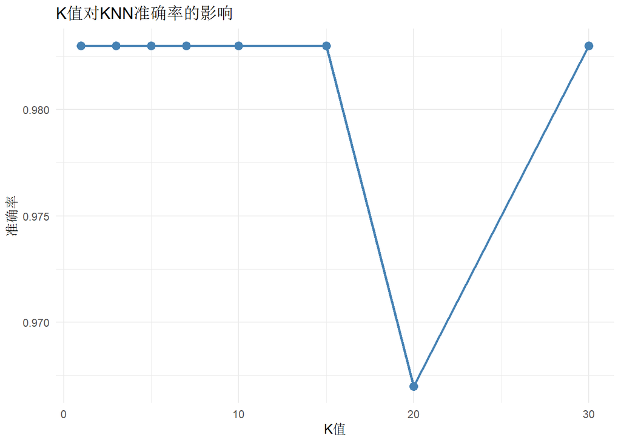

```r
# 可视化
ggplot2::ggplot(k_compare, ggplot2::aes(x = K值, y = 准确率)) +
  ggplot2::geom_line(color = "steelblue", linewidth = 1) +
  ggplot2::geom_point(size = 3, color = "steelblue") +
  ggplot2::labs(
    title = "K值对KNN准确率的影响",
    x = "K值", y = "准确率"
  ) +
  ggplot2::theme_minimal()
```

### 使用交叉验证选择K

```r
# 使用caret进行交叉验证选择K
set.seed(42)

tune_control <- caret::trainControl(method = "cv", number = 5)

knn_tune <- caret::train(
  class ~ feature1 + feature2,
  data = train_data,
  method = "knn",
  trControl = tune_control,
  tuneGrid = data.frame(k = 1:20)
)

print(knn_tune)
```

```
## k-Nearest Neighbors
##
## 140 samples
##   2 predictor
##   2 classes: 'A', 'B'
##
## No pre-processing
## Resampling: Cross-Validated (5 fold)
## Summary of sample sizes: 112, 112, 112, 113, 111
## Resampling results across tuning parameters:
##
##   k   Accuracy   Kappa
##    1  0.9785532  0.9569958
##    2  0.9714103  0.9427758
##    3  0.9925926  0.9851240
##    4  0.9925926  0.9851240
##    5  0.9925926  0.9851240
##    6  0.9925926  0.9851240
##    7  0.9925926  0.9851240
##    8  0.9856960  0.9712815
##    9  0.9925926  0.9851240
##   10  0.9856960  0.9712815
##   11  0.9856960  0.9712815
##   12  0.9856960  0.9712815
##   13  0.9856960  0.9712815
##   14  0.9925926  0.9851240
##   15  0.9856960  0.9712815
##   16  0.9925926  0.9851240
##   17  0.9925926  0.9851240
##   18  0.9925926  0.9851240
##   19  0.9925926  0.9851240
##   20  0.9925926  0.9851240
##
## Accuracy was used to select the optimal model using the largest value.
## The final value used for the model was k = 20.
```

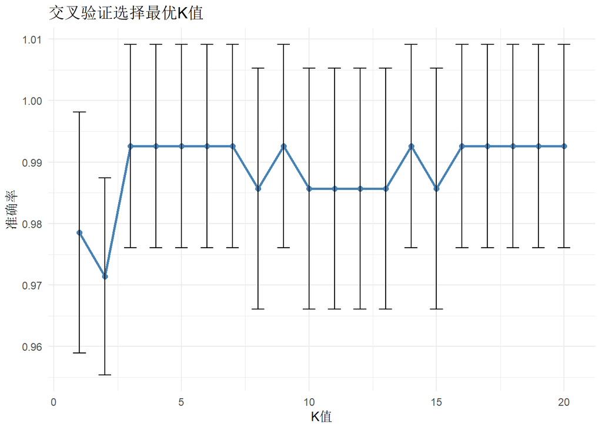

```r
# 可视化
ggplot2::ggplot(knn_tune$results, ggplot2::aes(x = k, y = Accuracy)) +
  ggplot2::geom_line(color = "steelblue", linewidth = 1) +
  ggplot2::geom_point(size = 2, color = "steelblue") +
  ggplot2::geom_errorbar(ggplot2::aes(ymin = Accuracy - AccuracySD,
                                       ymax = Accuracy + AccuracySD),
                         width = 0.5) +
  ggplot2::labs(
    title = "交叉验证选择最优K值",
    x = "K值", y = "准确率"
  ) +
  ggplot2::theme_minimal()
```

## 7.6 K-D树与球树

### 加速最近邻搜索

对于大规模数据，暴力搜索效率低。**K-D树**和**球树**是常用的加速结构。

**K-D树**：递归地将空间划分为超矩形区域。

**球树**：使用超球体划分空间，对高维数据更有效。

```r
# K-D树加速示意（概念演示）
# R中可以使用RANN包进行快速最近邻搜索

if (requireNamespace("RANN", quietly = TRUE)) {
  library(RANN)

  # 使用nn2函数快速查找最近邻
  nn_result <- RANN::nn2(
    data = train_data[, c("feature1", "feature2")],
    query = test_data[, c("feature1", "feature2")],
    k = 5
  )

  # nn_result$nn.idx 包含最近邻索引
  # nn_result$nn.dists 包含距离

  print("最近邻索引（前5个测试样本）：")
  print(head(nn_result$nn.idx))
}
```

```
## [1] "最近邻索引（前5个测试样本）："
##      [,1] [,2] [,3] [,4] [,5]
## [1,]   45   18   57   76   44
## [2,]   23  127   16   52  128
## [3,]   24   34  104   96   71
## [4,]   23  127   16   52   20
## [5,]   57   77   18   45   76
## [6,]   95  106   49   35  100
```

## 7.7 最近邻回归

### KNN回归

KNN也可用于回归问题，预测值为K个邻居的平均值或加权平均值。

```r
# KNN回归示例
set.seed(42)

# 创建回归数据
n <- 200
reg_data <- data.frame(
  x = runif(n, 0, 10),
  y = sin(runif(n, 0, 10)) + rnorm(n, 0, 0.3)
)

# 划分训练集和测试集
train_idx <- sample(1:n, 150)
train_reg <- reg_data[train_idx, ]
test_reg <- reg_data[-train_idx, ]

# 使用caret进行KNN回归
knn_reg <- caret::knnreg(
  y ~ x,
  data = train_reg,
  k = 5
)

# 预测
pred_reg <- predict(knn_reg, test_reg)

# 计算RMSE
rmse <- sqrt(mean((pred_reg - test_reg$y)^2))
print(paste("KNN回归RMSE:", round(rmse, 3)))
```

```
## [1] "KNN回归RMSE: 0.896"
```

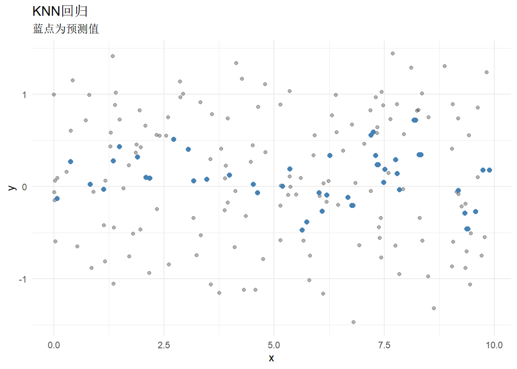

```r
# 可视化
test_reg$pred <- pred_reg

ggplot2::ggplot() +
  ggplot2::geom_point(data = train_reg, ggplot2::aes(x = x, y = y), alpha = 0.3) +
  ggplot2::geom_point(data = test_reg, ggplot2::aes(x = x, y = pred), color = "steelblue", size = 2) +
  ggplot2::labs(
    title = "KNN回归",
    subtitle = "蓝点为预测值",
    x = "x", y = "y"
  ) +
  ggplot2::theme_minimal()
```

## 7.8 局部加权回归

### LOWESS/LOESS

**局部加权回归（Locally Weighted Regression）**在每个预测点附近拟合一个局部回归模型。

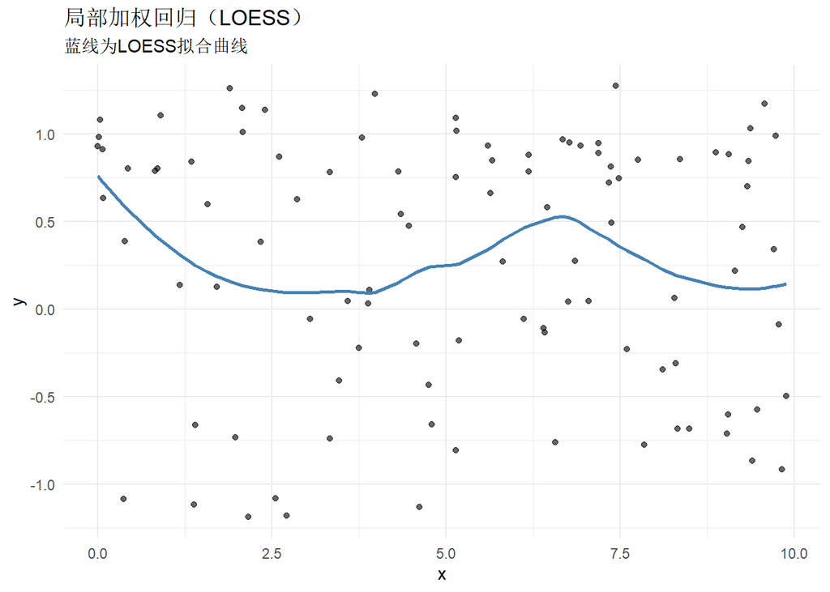

```r
# 局部加权回归示例
set.seed(42)

# 创建数据
n <- 100
lowess_data <- data.frame(
  x = runif(n, 0, 10),
  y = sin(runif(n, 0, 10)) + rnorm(n, 0, 0.2)
)

# 使用loess进行局部加权回归
loess_model <- loess(y ~ x, data = lowess_data, span = 0.5)

# 预测
x_sorted <- sort(lowess_data$x)
y_pred <- predict(loess_model, newdata = data.frame(x = x_sorted))

# 可视化
ggplot2::ggplot(lowess_data, ggplot2::aes(x = x, y = y)) +
  ggplot2::geom_point(alpha = 0.6) +
  ggplot2::geom_line(data = data.frame(x = x_sorted, y = y_pred),
                     ggplot2::aes(x = x, y = y), color = "steelblue", linewidth = 1) +
  ggplot2::labs(
    title = "局部加权回归（LOESS）",
    subtitle = "蓝线为LOESS拟合曲线",
    x = "x", y = "y"
  ) +
  ggplot2::theme_minimal()
```

### span参数的影响

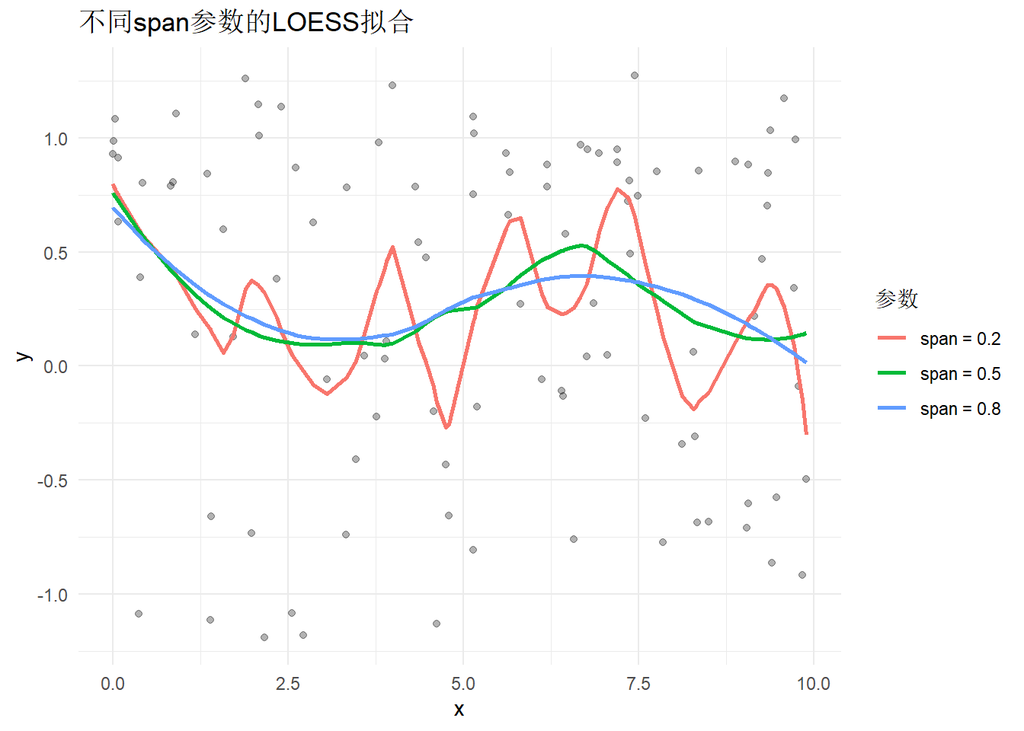

```r
# 比较不同span值
span_values <- c(0.2, 0.5, 0.8)
colors <- c("red", "steelblue", "green")

plot_data <- data.frame()
for (i in seq_along(span_values)) {
  model <- loess(y ~ x, data = lowess_data, span = span_values[i])
  pred <- predict(model, newdata = data.frame(x = x_sorted))
  plot_data <- rbind(plot_data, data.frame(
    x = x_sorted,
    y = pred,
    span = paste("span =", span_values[i])
  ))
}

ggplot2::ggplot() +
  ggplot2::geom_point(data = lowess_data, ggplot2::aes(x = x, y = y), alpha = 0.3) +
  ggplot2::geom_line(data = plot_data, ggplot2::aes(x = x, y = y, color = span), linewidth = 1) +
  ggplot2::labs(
    title = "不同span参数的LOESS拟合",
    x = "x", y = "y", color = "参数"
  ) +
  ggplot2::theme_minimal()
```

## 7.9 意义与使用场景

### 核心意义

KNN和基于实例的方法是**懒惰学习**的代表，不需要显式的训练过程，直接存储训练数据。

### 优缺点

| 优点 | 缺点 |
| --- | --- |
| 简单直观 | 预测速度慢 |
| 无需训练 | 需要大量存储 |
| 可处理多分类 | 对特征缩放敏感 |
| 可处理非线性 | 高维数据效果差 |

### 适用场景

**举例**：医学诊断参考

**场景**：根据患者的症状和检查结果，参考相似病例进行诊断。

**为什么用KNN？**

医学诊断中，相似病例往往有相似的诊断结果。KNN可以找到历史上最相似的病例，为医生提供参考。医生可以查看这些相似病例的治疗方案和预后，辅助决策。

### KNN vs 其他方法

| 场景 | 推荐方法 |
| --- | --- |
| 小数据、低维 | KNN |
| 大数据、高维 | SVM、树模型 |
| 需要解释性 | 决策树 |
| 需要概率输出 | 逻辑回归 |

# 第八章 贝叶斯与概率图模型

## 8.1 朴素贝叶斯分类器

### 贝叶斯定理

**贝叶斯定理**描述了条件概率之间的关系：

$$P(A|B) = \frac{P(B|A) \cdot
P(A)}{P(B)}$$

在分类问题中：

$$P(y|x) = \frac{P(x|y) \cdot
P(y)}{P(x)}$$

### 朴素贝叶斯假设

**朴素贝叶斯**假设特征之间相互独立：

$$P(x|y) = \prod_{j=1}^{p}
P(x_j|y)$$

**分类决策**：

$$\hat{y} = \arg\max_y P(y)
\prod_{j=1}^{p} P(x_j|y)$$

### 三种朴素贝叶斯模型

| 模型 | 特征类型 | 分布假设 |
| --- | --- | --- |
| 高斯朴素贝叶斯 | 连续特征 | 高斯分布 |
| 多项式朴素贝叶斯 | 计数特征 | 多项式分布 |
| 伯努利朴素贝叶斯 | 二值特征 | 伯努利分布 |

```r
# 高斯朴素贝叶斯示例
set.seed(42)

# 使用iris数据集
data(iris)

# 划分训练集和测试集
train_idx <- sample(1:nrow(iris), 0.7 * nrow(iris))
train_iris <- iris[train_idx, ]
test_iris <- iris[-train_idx, ]

# 训练高斯朴素贝叶斯
nb_gaussian <- e1071::naiveBayes(Species ~ ., data = train_iris)

# 预测
nb_pred <- predict(nb_gaussian, test_iris)

# 混淆矩阵
conf_matrix <- table(实际 = test_iris$Species, 预测 = nb_pred)
print(conf_matrix)
```

```
##             预测
## 实际       setosa versicolor virginica
##   setosa         12          0         0
##   versicolor      0         14         1
##   virginica       0          1        17
```

```r
# 准确率
accuracy <- mean(nb_pred == test_iris$Species)
print(paste("高斯朴素贝叶斯准确率:", round(accuracy, 3)))
```

```
## [1] "高斯朴素贝叶斯准确率: 0.956"
```

### 查看模型参数

```r
# 查看各类别的先验概率
print("先验概率:")
```

```
## [1] "先验概率:"
```

```r
print(nb_gaussian$apriori)
```

```
## Y
##     setosa versicolor  virginica
##         38         35         32
```

```r
# 查看各特征的条件概率参数（均值和标准差）
print("条件概率参数:")
```

```
## [1] "条件概率参数:"
```

```r
print(nb_gaussian$tables)
```

```
## $Sepal.Length
##             Sepal.Length
## Y                [,1]      [,2]
##   setosa     5.015789 0.3405293
##   versicolor 5.874286 0.5135476
##   virginica  6.606250 0.6983564
##
## $Sepal.Width
##             Sepal.Width
## Y                [,1]      [,2]
##   setosa     3.426316 0.4084805
##   versicolor 2.745714 0.3229850
##   virginica  2.996875 0.3560395
##
## $Petal.Length
##             Petal.Length
## Y                [,1]      [,2]
##   setosa     1.447368 0.1389864
##   versicolor 4.217143 0.5176222
##   virginica  5.543750 0.5529612
##
## $Petal.Width
##             Petal.Width
## Y                 [,1]      [,2]
##   setosa     0.2473684 0.1156342
##   versicolor 1.3228571 0.2001260
##   virginica  2.0125000 0.2836968
```

### 多项式朴素贝叶斯

```r
# 多项式朴素贝叶斯示例：文本分类
set.seed(42)

# 创建模拟文本数据
n <- 200
text_data <- data.frame(
  word1 = rpois(n, lambda = sample(c(2, 5, 1), n, replace = TRUE)),
  word2 = rpois(n, lambda = sample(c(3, 1, 4), n, replace = TRUE)),
  word3 = rpois(n, lambda = sample(c(1, 3, 2), n, replace = TRUE)),
  category = factor(sample(c("医疗", "体育", "科技"), n, replace = TRUE))
)

# 划分训练集和测试集
train_idx <- sample(1:n, 150)
train_text <- text_data[train_idx, ]
test_text <- text_data[-train_idx, ]

# 训练多项式朴素贝叶斯
nb_multinomial <- e1071::naiveBayes(category ~ ., data = train_text, type = "raw")

# 预测
pred_text <- predict(nb_multinomial, test_text)

# 准确率
accuracy <- mean(pred_text == test_text$category)
print(paste("多项式朴素贝叶斯准确率:", round(accuracy, 3)))
```

```
## [1] "多项式朴素贝叶斯准确率: 0.34"
```

### 伯努利朴素贝叶斯

```r
# 伯努利朴素贝叶斯示例
set.seed(42)

# 创建二值特征数据
n <- 200
binary_data <- data.frame(
  symptom1 = sample(c(0, 1), n, replace = TRUE),
  symptom2 = sample(c(0, 1), n, replace = TRUE),
  symptom3 = sample(c(0, 1), n, replace = TRUE),
  symptom4 = sample(c(0, 1), n, replace = TRUE),
  disease = factor(sample(c("健康", "患病"), n, replace = TRUE, prob = c(0.7, 0.3)))
)

# 划分数据
train_idx <- sample(1:n, 150)
train_binary <- binary_data[train_idx, ]
test_binary <- binary_data[-train_idx, ]

# 训练伯努利朴素贝叶斯
nb_bernoulli <- e1071::naiveBayes(disease ~ ., data = train_binary)

# 预测
pred_binary <- predict(nb_bernoulli, test_binary)

# 准确率
accuracy <- mean(pred_binary == test_binary$disease)
print(paste("伯努利朴素贝叶斯准确率:", round(accuracy, 3)))
```

```
## [1] "伯努利朴素贝叶斯准确率: 0.7"
```

## 8.2 高斯判别分析（GDA）

### GDA原理

**高斯判别分析**假设各类别的数据服从多元高斯分布：

$$P(x|y=k) =
\frac{1}{(2\pi)^{p/2}|\Sigma_k|^{1/2}} \exp\left(-\frac{1}{2}(x-\mu_k)^T
\Sigma_k^{-1} (x-\mu_k)\right)$$

```r
# GDA示例（使用MASS包的lda函数）
set.seed(42)

# 使用iris数据
gda_model <- MASS::lda(Species ~ ., data = train_iris)

# 查看模型
print(gda_model)
```

```
## Call:
## lda(Species ~ ., data = train_iris)
##
## Prior probabilities of groups:
##     setosa versicolor  virginica
##  0.3619048  0.3333333  0.3047619
##
## Group means:
##            Sepal.Length Sepal.Width Petal.Length Petal.Width
## setosa         5.015789    3.426316     1.447368   0.2473684
## versicolor     5.874286    2.745714     4.217143   1.3228571
## virginica      6.606250    2.996875     5.543750   2.0125000
##
## Coefficients of linear discriminants:
##                    LD1        LD2
## Sepal.Length  1.084659 -0.1357075
## Sepal.Width   1.221953 -2.0950103
## Petal.Length -2.431518  0.8233400
## Petal.Width  -2.643108 -2.4996356
##
## Proportion of trace:
##    LD1    LD2
## 0.9916 0.0084
```

```r
# 预测
gda_pred <- predict(gda_model, test_iris)

# 混淆矩阵
table(实际 = test_iris$Species, 预测 = gda_pred$class)
```

```
##             预测
## 实际       setosa versicolor virginica
##   setosa         12          0         0
##   versicolor      0         15         0
##   virginica       0          1        17
```

```r
# 准确率
accuracy <- mean(gda_pred$class == test_iris$Species)
print(paste("GDA准确率:", round(accuracy, 3)))
```

```
## [1] "GDA准确率: 0.978"
```

### GDA vs 朴素贝叶斯

| 特点 | GDA | 朴素贝叶斯 |
| --- | --- | --- |
| 特征独立性 | 不假设独立 | 假设独立 |
| 参数数量 | 多 | 少 |
| 数据需求 | 大 | 小 |
| 灵活性 | 高 | 低 |

## 8.3 贝叶斯网络基础

### 贝叶斯网络概念

**贝叶斯网络**是一种概率图模型，用有向无环图（DAG）表示变量之间的依赖关系。

**组成**： - **节点**：随机变量 - **边**：依赖关系 - **条件概率表（CPT）**：每个节点的条件概率分布

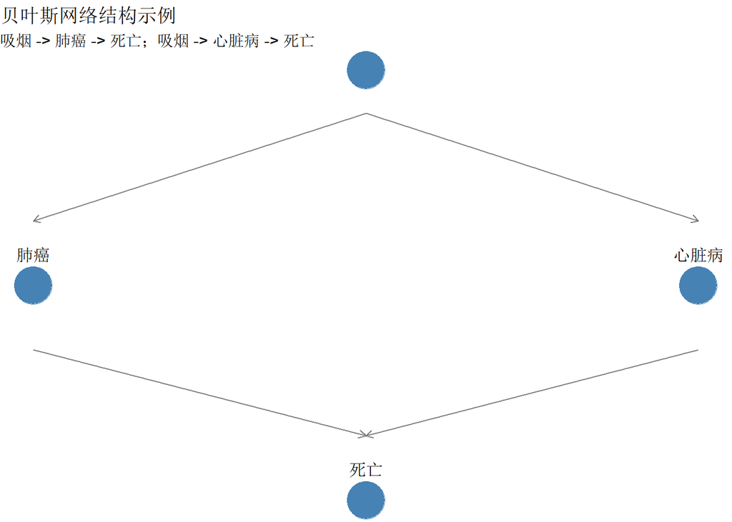

```r
# 贝叶斯网络示例（概念演示）
# 使用bnlearn包（如果可用）

if (requireNamespace("bnlearn", quietly = TRUE)) {
  library(bnlearn)

  # 创建一个简单的贝叶斯网络结构
  # 假设：吸烟 -> 肺癌 -> 死亡；吸烟 -> 心脏病 -> 死亡

  # 定义网络结构
  dag <- model2network("[吸烟][肺癌|吸烟][心脏病|吸烟][死亡|肺癌:心脏病]")

  # 可视化网络结构
  graphviz.chart(dag, main = "贝叶斯网络结构示例")

} else {
  # 手动绘制贝叶斯网络概念图
  bn_nodes <- data.frame(
    node = c("吸烟", "肺癌", "心脏病", "死亡"),
    x = c(1, 0.5, 1.5, 1),
    y = c(3, 2, 2, 1)
  )

  ggplot2::ggplot() +
    ggplot2::geom_segment(ggplot2::aes(x = 1, xend = 0.5, y = 2.8, yend = 2.3),
                          arrow = ggplot2::arrow(length = ggplot2::unit(0.2, "cm")), color = "gray50") +
    ggplot2::geom_segment(ggplot2::aes(x = 1, xend = 1.5, y = 2.8, yend = 2.3),
                          arrow = ggplot2::arrow(length = ggplot2::unit(0.2, "cm")), color = "gray50") +
    ggplot2::geom_segment(ggplot2::aes(x = 0.5, xend = 1, y = 1.7, yend = 1.3),
                          arrow = ggplot2::arrow(length = ggplot2::unit(0.2, "cm")), color = "gray50") +
    ggplot2::geom_segment(ggplot2::aes(x = 1.5, xend = 1, y = 1.7, yend = 1.3),
                          arrow = ggplot2::arrow(length = ggplot2::unit(0.2, "cm")), color = "gray50") +
    ggplot2::geom_point(data = bn_nodes, ggplot2::aes(x = x, y = y), size = 12, color = "steelblue") +
    ggplot2::geom_text(data = bn_nodes, ggplot2::aes(x = x, y = y, label = node), vjust = -2, size = 4) +
    ggplot2::labs(
      title = "贝叶斯网络结构示例",
      subtitle = "吸烟 -> 肺癌 -> 死亡；吸烟 -> 心脏病 -> 死亡"
    ) +
    ggplot2::theme_void()
}
```

### 条件独立性

贝叶斯网络的关键性质是**条件独立性**：

$$P(X_1, X_2, ..., X_n) = \prod_{i=1}^{n}
P(X_i | Parents(X_i))$$

## 8.4 隐马尔可夫模型（HMM）基础概念

### HMM基本要素

**隐马尔可夫模型**用于建模序列数据，包含：

1. **隐藏状态序列**：不可观测的状态
2. **观测序列**：可观测的输出
3. **三个核心参数**：
   - 初始概率$\pi$
   - 转移概率$A$
   - 发射概率$B$

```r
# HMM概念示意
# 创建一个简单的疾病状态转移模型

# 状态：健康(H)、疾病(S)
# 观测：正常检查结果(N)、异常检查结果(A)

# 转移概率矩阵
transition_matrix <- matrix(
  c(0.9, 0.1,    # H -> H, H -> S
    0.3, 0.7),   # S -> H, S -> S
  nrow = 2, byrow = TRUE
)
rownames(transition_matrix) <- c("健康", "疾病")
colnames(transition_matrix) <- c("健康", "疾病")

print("转移概率矩阵:")
```

```
## [1] "转移概率矩阵:"
```

```r
print(transition_matrix)
```

```
##      健康 疾病
## 健康  0.9  0.1
## 疾病  0.3  0.7
```

```r
# 发射概率矩阵
emission_matrix <- matrix(
  c(0.8, 0.2,    # H -> N, H -> A
    0.3, 0.7),   # S -> N, S -> A
  nrow = 2, byrow = TRUE
)
rownames(emission_matrix) <- c("健康", "疾病")
colnames(emission_matrix) <- c("正常", "异常")

print("发射概率矩阵:")
```

```
## [1] "发射概率矩阵:"
```

```r
print(emission_matrix)
```

```
##      正常 异常
## 健康  0.8  0.2
## 疾病  0.3  0.7
```

```r
# 初始概率
initial_prob <- c(健康 = 0.9, 疾病 = 0.1)
print("初始概率:")
```

```
## [1] "初始概率:"
```

```r
print(initial_prob)
```

```
## 健康 疾病
##  0.9  0.1
```

### HMM可视化

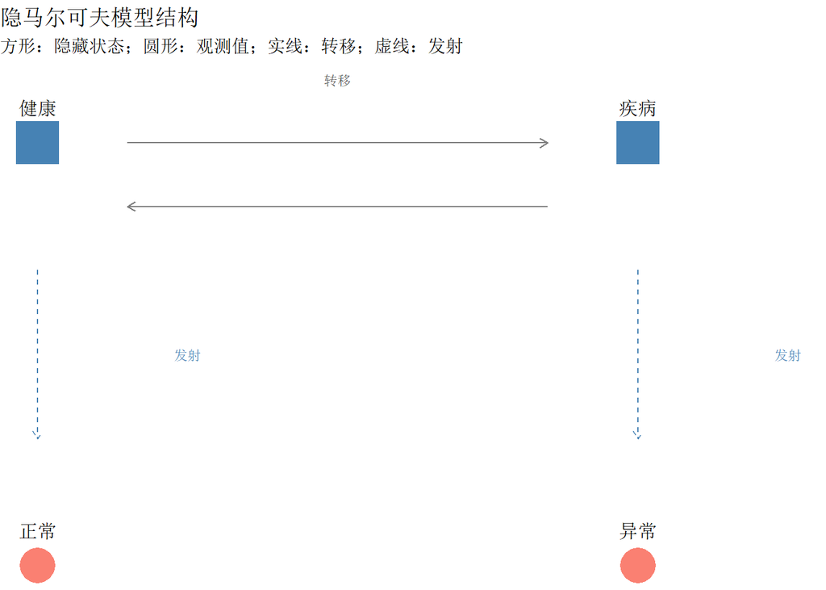

```r
# 可视化HMM结构
hmm_states <- data.frame(
  state = c("健康", "疾病"),
  x = c(1, 3),
  y = c(2, 2)
)

hmm_obs <- data.frame(
  obs = c("正常", "异常"),
  x = c(1, 3),
  y = c(1, 1)
)

ggplot2::ggplot() +
  ggplot2::geom_segment(ggplot2::aes(x = 1.3, xend = 2.7, y = 2, yend = 2),
                        arrow = ggplot2::arrow(length = ggplot2::unit(0.2, "cm")), color = "gray50") +
  ggplot2::geom_segment(ggplot2::aes(x = 2.7, xend = 1.3, y = 1.85, yend = 1.85),
                        arrow = ggplot2::arrow(length = ggplot2::unit(0.2, "cm")), color = "gray50") +
  ggplot2::geom_segment(ggplot2::aes(x = 1, xend = 1, y = 1.7, yend = 1.3),
                        arrow = ggplot2::arrow(length = ggplot2::unit(0.2, "cm")), color = "steelblue", linetype = "dashed") +
  ggplot2::geom_segment(ggplot2::aes(x = 3, xend = 3, y = 1.7, yend = 1.3),
                        arrow = ggplot2::arrow(length = ggplot2::unit(0.2, "cm")), color = "steelblue", linetype = "dashed") +
  ggplot2::geom_point(data = hmm_states, ggplot2::aes(x = x, y = y),
                       size = 12, color = "steelblue", shape = 15) +
  ggplot2::geom_point(data = hmm_obs, ggplot2::aes(x = x, y = y),
                       size = 10, color = "salmon", shape = 16) +
  ggplot2::geom_text(data = hmm_states, ggplot2::aes(x = x, y = y, label = state),
                      vjust = -2, size = 4) +
  ggplot2::geom_text(data = hmm_obs, ggplot2::aes(x = x, y = y, label = obs),
                      vjust = -2, size = 4) +
  ggplot2::annotate("text", x = 2, y = 2.15, label = "转移", size = 3, color = "gray30") +
  ggplot2::annotate("text", x = 1.5, y = 1.5, label = "发射", size = 3, color = "steelblue") +
  ggplot2::annotate("text", x = 3.5, y = 1.5, label = "发射", size = 3, color = "steelblue") +
  ggplot2::labs(
    title = "隐马尔可夫模型结构",
    subtitle = "方形：隐藏状态；圆形：观测值；实线：转移；虚线：发射"
  ) +
  ggplot2::theme_void()
```

### HMM的三个基本问题

1. **评估问题**：给定模型，计算观测序列的概率（前向算法）
2. **解码问题**：给定观测序列，求最可能的状态序列（Viterbi算法）
3. **学习问题**：估计模型参数（Baum-Welch算法）

## 8.5 高斯过程基础

### 高斯过程概念

**高斯过程（Gaussian Process, GP）**是一种非参数贝叶斯方法，定义了函数的分布。

**定义**：对于任意输入点集合$\{x_1, ..., x_n\}$，函数值$\{f(x_1), ..., f(x_n)\}$服从多元高斯分布。

**核心要素**： - **均值函数** $m(x)$ - **协方差函数（核函数）** $k(x, x')$

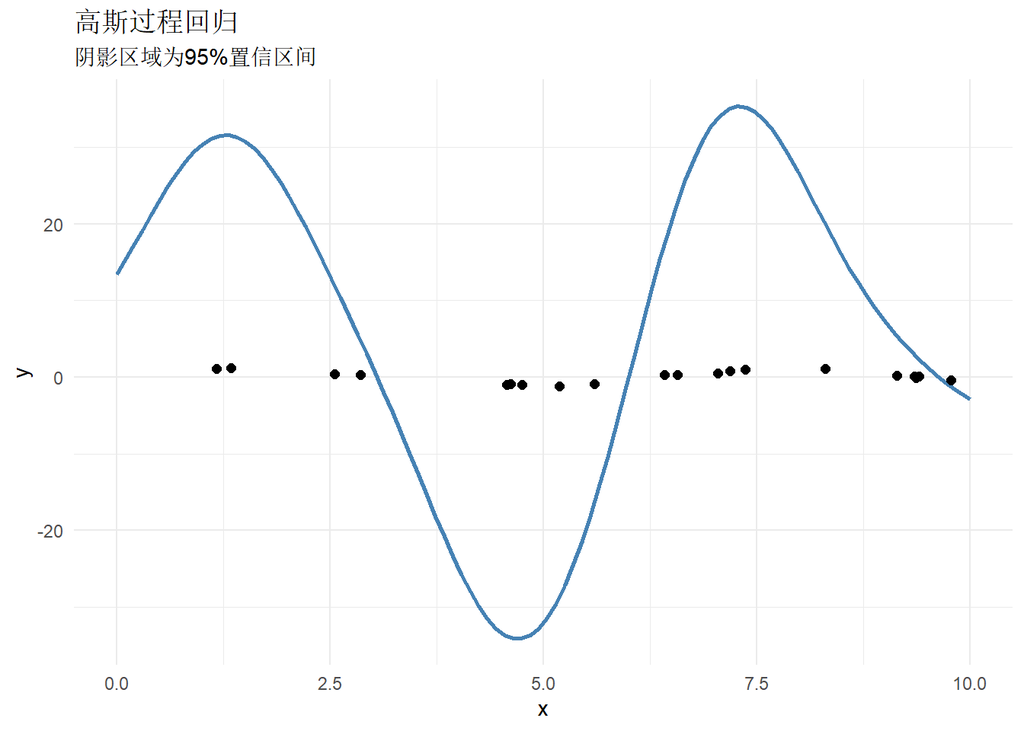

```r
# 高斯过程回归示例
set.seed(42)

# 创建数据
n_train <- 20
x_train <- sort(runif(n_train, 0, 10))
y_train <- sin(x_train) + rnorm(n_train, 0, 0.1)

# 测试点
x_test <- seq(0, 10, length.out = 100)

# 定义RBF核函数
rbf_kernel <- function(x1, x2, sigma = 1, length_scale = 1) {
  sigma^2 * exp(-0.5 * (outer(x1, x2, "-") / length_scale)^2)
}

# 计算协方差矩阵
K <- rbf_kernel(x_train, x_train)
K_star <- rbf_kernel(x_test, x_train)
K_star_star <- rbf_kernel(x_test, x_test)

# 添加噪声
sigma_n <- 0.1
K_noise <- K + sigma_n^2 * diag(n_train)

# 高斯过程预测
L <- chol(K_noise)
alpha <- solve(t(L), solve(L, y_train))
y_pred <- K_star %*% alpha

# 计算预测方差
v <- solve(L, t(K_star))
y_var <- diag(K_star_star) - colSums(v^2)
y_sd <- sqrt(pmax(y_var, 0))

# 可视化
gp_data <- data.frame(
  x = x_test,
  y_mean = as.vector(y_pred),
  y_lower = as.vector(y_pred - 1.96 * y_sd),
  y_upper = as.vector(y_pred + 1.96 * y_sd)
)

ggplot2::ggplot() +
  ggplot2::geom_ribbon(data = gp_data, ggplot2::aes(x = x, ymin = y_lower, ymax = y_upper),
                        fill = "steelblue", alpha = 0.3) +
  ggplot2::geom_line(data = gp_data, ggplot2::aes(x = x, y = y_mean), color = "steelblue", linewidth = 1) +
  ggplot2::geom_point(data = data.frame(x = x_train, y = y_train),
                       ggplot2::aes(x = x, y = y), size = 2) +
  ggplot2::labs(
    title = "高斯过程回归",
    subtitle = "阴影区域为95%置信区间",
    x = "x", y = "y"
  ) +
  ggplot2::theme_minimal()
```

### 核函数的选择

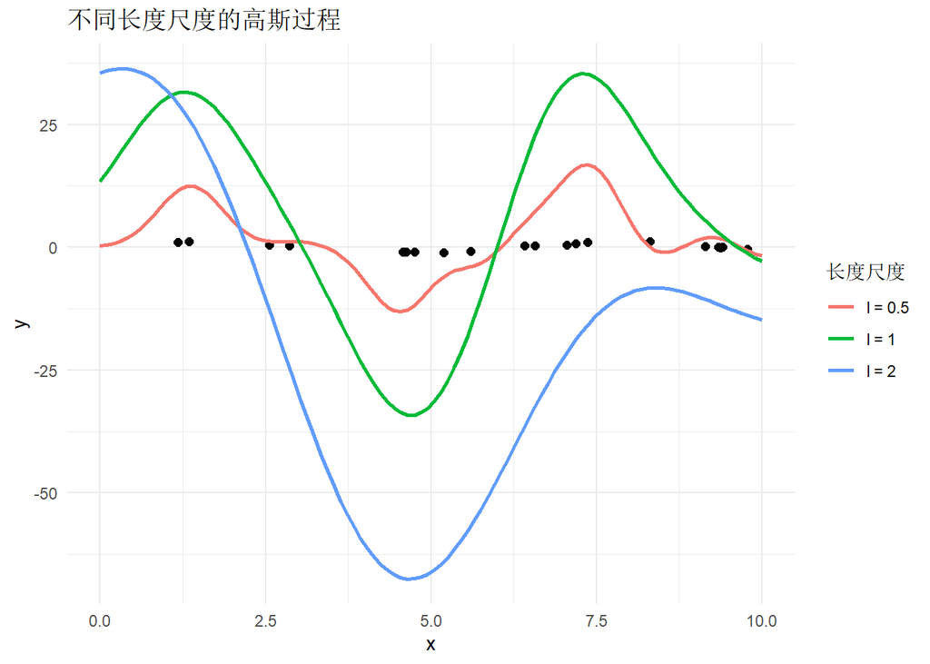

```r
# 比较不同长度尺度
length_scales <- c(0.5, 1, 2)

gp_compare <- data.frame()

for (l in length_scales) {
  K <- rbf_kernel(x_train, x_train, length_scale = l)
  K_star <- rbf_kernel(x_test, x_train, length_scale = l)
  K_star_star <- rbf_kernel(x_test, x_test, length_scale = l)

  K_noise <- K + sigma_n^2 * diag(n_train)
  L <- chol(K_noise)
  alpha <- solve(t(L), solve(L, y_train))
  y_pred <- K_star %*% alpha

  gp_compare <- rbind(gp_compare, data.frame(
    x = x_test,
    y = as.vector(y_pred),
    length_scale = paste("l =", l)
  ))
}

ggplot2::ggplot() +
  ggplot2::geom_point(data = data.frame(x = x_train, y = y_train),
                       ggplot2::aes(x = x, y = y), size = 2) +
  ggplot2::geom_line(data = gp_compare, ggplot2::aes(x = x, y = y, color = length_scale), linewidth = 1) +
  ggplot2::labs(
    title = "不同长度尺度的高斯过程",
    x = "x", y = "y", color = "长度尺度"
  ) +
  ggplot2::theme_minimal()
```

### 高斯过程的特点

| 优点 | 缺点 |
| --- | --- |
| 提供不确定性估计 | 计算复杂度高$O(n^3)$ |
| 非参数、灵活 | 大数据集难以处理 |
| 自动处理噪声 | 核函数选择困难 |

## 8.6 意义与使用场景

### 核心意义

贝叶斯方法提供了概率框架下的机器学习方法，能够：

1. **量化不确定性**：输出概率分布而非点估计
2. **融入先验知识**：通过先验分布引入领域知识
3. **处理小样本**：在数据有限时仍能给出合理估计

### 各方法适用场景

| 方法 | 适用场景 |
| --- | --- |
| 朴素贝叶斯 | 文本分类、高维稀疏数据 |
| GDA | 低维连续数据、类别分离明显 |
| 贝叶斯网络 | 变量间有明确依赖关系 |
| HMM | 序列数据、时间序列 |
| 高斯过程 | 小样本回归、不确定性估计 |

### 医学应用举例

**场景**：疾病诊断与预后预测

**为什么用贝叶斯方法？**

1. **朴素贝叶斯**：根据症状快速筛查疾病
2. **贝叶斯网络**：建模疾病与风险因素之间的因果关系
3. **HMM**：分析疾病进展过程，预测患者状态变化
4. **高斯过程**：预测药物剂量-效应曲线，提供置信区间

## 总结

本教程涵盖了机器学习的核心概念和方法：

**第一章**：机器学习基础概念，包括学习范式、问题类型、模型评估基础

**第二章**：数据预处理与特征工程，是机器学习成功的关键步骤

**第三章**：模型评估与验证，确保模型泛化能力

**第四章**：线性模型，机器学习的基础

**第五章**：树模型与集成学习，处理复杂非线性关系

**第六章**：支持向量机与核方法，高维数据的利器

**第七章**：最近邻与基于实例的方法，简单直观的非参数方法

**第八章**：贝叶斯与概率图模型，概率框架下的学习方法

### 学习建议

1. **理论与实践结合**：每学完一个方法，用真实数据实践
2. **理解原理**：不仅会用包，更要理解背后的数学原理
3. **比较实验**：同一问题尝试不同方法，比较优劣
4. **关注医学应用**：将机器学习方法与医学实际问题结合

### 进阶学习方向

- 深度学习与神经网络
- 强化学习
- 因果推断
- 联邦学习与隐私保护
- 可解释机器学习